# Reproducible Research: Peer Assessment 1

## Introduction

This assignment makes use of data from a activity monitoring device. The device collects data at 5 minute intervals through out the day.

## Dataset

The variables included in this dataset are:

- steps: Number of steps taking in a 5-minute interval (missing values are coded as NA)
- date: The date on which the measurement was taken in YYYY-MM-DD format
- interval: Identifier for the 5-minute interval in which measurement was taken

The dataset is stored in a comma-separated-value (CSV) file and there are a total of 17,568 observations in this dataset.

## Load required libraries used in the analysis

```r
rm(list = ls())
library(dplyr)
```

```r
library(ggplot2)
library(gridExtra)
library(lubridate)
```

## Load activity data

```r
data <- read.csv(file = "C:/Users/manol/Documents/GitHub/RepData_PeerAssessment1/activity.csv")
```

## Overview and summary of data

```r
head(data)
```

```
##   steps       date interval
## 1    NA 2012-10-01        0
## 2    NA 2012-10-01        5
## 3    NA 2012-10-01       10
## 4    NA 2012-10-01       15
## 5    NA 2012-10-01       20
## 6    NA 2012-10-01       25
```

```r
summary(data)
```

```
##      steps                date          interval
##  Min.   :  0.00   2012-10-01:  288   Min.   :   0.0
##  1st Qu.:  0.00   2012-10-02:  288   1st Qu.: 588.8
##  Median :  0.00   2012-10-03:  288   Median :1177.5
##  Mean   : 37.38   2012-10-04:  288   Mean   :1177.5
##  3rd Qu.: 12.00   2012-10-05:  288   3rd Qu.:1766.2
##  Max.   :806.00   2012-10-06:  288   Max.   :2355.0
##  NA's   :2304     (Other)   :15840
```

## What is mean total number of steps taken per day?

```r
step_day <- aggregate(data$steps, by = list(Date = data$date),
                      FUN = sum)
step_day <- rename(step_day, Total_Steps = x)
head(step_day)
```

```
##         Date Total_Steps
## 1 2012-10-01          NA
## 2 2012-10-02         126
## 3 2012-10-03       11352
## 4 2012-10-04       12116
## 5 2012-10-05       13294
## 6 2012-10-06       15420
```

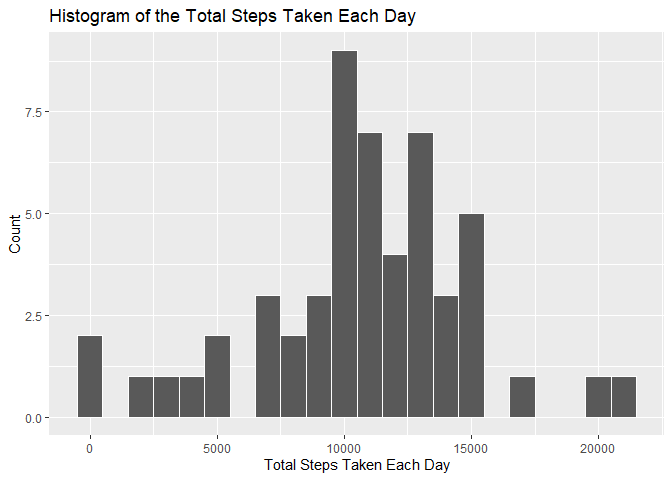

```r
hist_step_day <-
    ggplot(data = na.omit(step_day), aes(Total_Steps)) +
    geom_histogram(binwidth = 1000, colour = "white") +
    xlab("Total Steps Taken Each Day") +
    ylab("Count") +
    ggtitle("Histogram of the Total Steps Taken Each Day")
hist_step_day
```

Mean of the total number of steps taken per day

```r
mean(step_day$Total_Steps, na.rm = TRUE)
```

```
## [1] 10766.19
```

Median of the total number of steps taken per day

```r
median(step_day$Total_Steps, na.rm = TRUE)
```

```
## [1] 10765
```

## What is the average daily activity pattern?

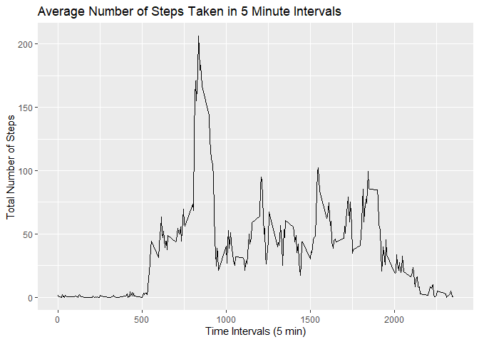

```r
min_interval_data <- data %>%
    select(interval, steps) %>%
    na.omit() %>%
    group_by(interval) %>%
    summarize(Total_Steps = mean(steps))

ggplot(min_interval_data,
       aes(x = interval,
           y = Total_Steps)) +

    geom_line() +
    xlab("Time Intervals (5 min)") +
    ylab("Total Number of Steps") +
    ggtitle("Average Number of Steps Taken in 5 Minute Intervals")
```

Which 5 minute interval, on average across all days in the dataset, contains the maximum number of steps?

```r
min_interval_data[which.max(min_interval_data$Total_Steps), ]
```

```
## # A tibble: 1 x 2
##   interval Total_Steps
##      <int>       <dbl>
## 1      835        206.
```

## Imputing missing values

Total number of missing values in the dataset

```r
colSums(is.na(data))
```

```
##    steps     date interval
##     2304        0        0
```

Replace the missing values with the mean

```r
rep_na_mean <- function(x)
    replace(x,
            is.na(x),
            mean(x, na.rm = TRUE))

mean_dat <- data %>%
    group_by(interval) %>%
    mutate(steps = rep_na_mean(steps))

head(mean_dat)
```

```
## # A tibble: 6 x 3
## # Groups:   interval [6]
##    steps date       interval
##    <dbl> <fct>         <int>
## 1 1.72   2012-10-01        0
## 2 0.340  2012-10-01        5
## 3 0.132  2012-10-01       10
## 4 0.151  2012-10-01       15
## 5 0.0755 2012-10-01       20
## 6 2.09   2012-10-01       25
```

```r
#Count NA
colSums(is.na(mean_dat))
```

```
##    steps     date interval
##        0        0        0
```

Create a dataset without missing values and make a histogram of the total number of steps taken each day

```r
#Calulate total steps per day
step_day_rep_na <- aggregate(mean_dat$steps,
                             by = list(Date = mean_dat$date),
                             FUN = sum)

step_day_rep_na <- rename(step_day_rep_na,
                          Total_Steps = x)
head(step_day_rep_na)
```

```
##         Date Total_Steps
## 1 2012-10-01    10766.19
## 2 2012-10-02      126.00
## 3 2012-10-03    11352.00
## 4 2012-10-04    12116.00
## 5 2012-10-05    13294.00
## 6 2012-10-06    15420.00
```

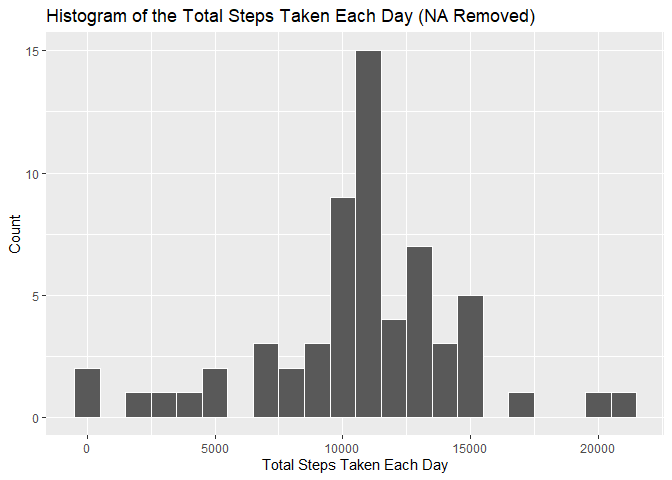

```r
#Plot histogram of new data
hist_na_rm <- ggplot(data = step_day_rep_na, aes(Total_Steps)) +
    geom_histogram(binwidth = 1000, colour = "white") +
    xlab("Total Steps Taken Each Day") +
    ylab("Count") +
    ggtitle("Histogram of the Total Steps Taken Each Day (NA Removed)")

hist_na_rm
```

Mean of the total number of steps taken per day

```r
mean(step_day_rep_na$Total_Steps)
```

```
## [1] 10766.19
```

Median of the total number of steps taken per day

```r
median(step_day_rep_na$Total_Steps)
```

```
## [1] 10766.19
```

## Impact of imputing missing data

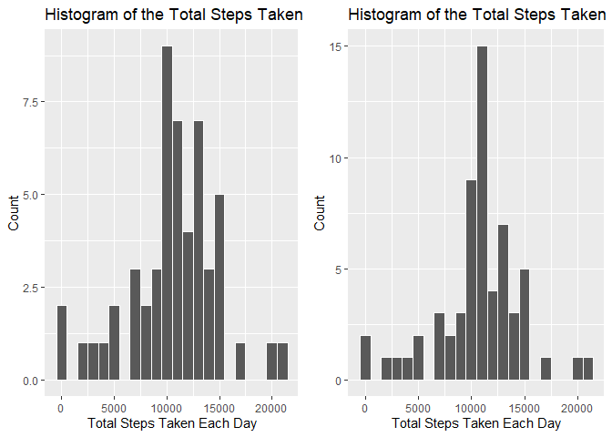

```r
#Histogram plots of total steps a day.
grid.arrange(hist_step_day, hist_na_rm, ncol = 2)
```

```r
#Mean Old
old_mean<-mean(step_day$Total_Steps, na.rm = TRUE)
#Mean New
new_mean<-mean(step_day_rep_na$Total_Steps)

#Median Old
old_med<-median(step_day$Total_Steps, na.rm = TRUE)
#Median New
new_med<-median(step_day_rep_na$Total_Steps)
```

The impact of inputting missing data is minimal, as only the median seems to be changing.

```r
#Difference between old and new mean
(old_mean-new_mean)
```

```
## [1] 0
```

```r
#Difference between old and new median
(old_med-new_med)
```

```
## [1] -1.188679
```

## Are there differences in activity patterns between weekdays and weekends?

```r
data_we_wd<-data%>%
    mutate(Week_name = wday(date,label = TRUE),
           Weekend_Indicator = if_else(Week_name == "Sat"|Week_name == "Sun",
                            "Weekend","Weekday"))%>%
    select(interval,Weekend_Indicator,steps)


data_we_wd<-aggregate(.~interval+Weekend_Indicator,data_we_wd,mean)
head(data_we_wd)
```

```
##   interval Weekend_Indicator     steps
## 1        0           Weekday 2.3333333
## 2        5           Weekday 0.4615385
## 3       10           Weekday 0.1794872
## 4       15           Weekday 0.2051282
## 5       20           Weekday 0.1025641
## 6       25           Weekday 1.5128205
```

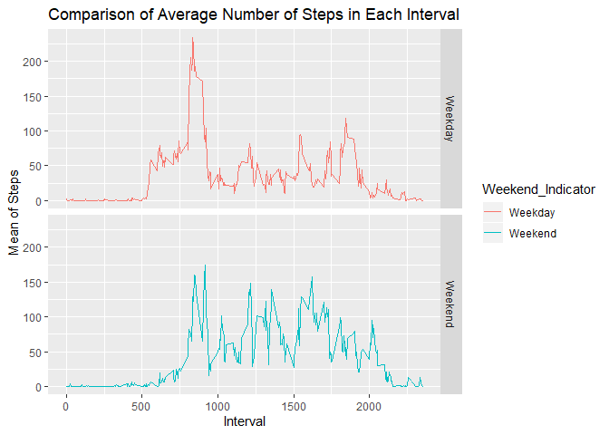

```r
ggplot(data_we_wd,aes(x=interval, y=steps, color=Weekend_Indicator))+
    geom_line()+
    facet_grid(Weekend_Indicator ~.) +
    xlab("Interval") +
    ylab("Mean of Steps") +
    ggtitle("Comparison of Average Number of Steps in Each Interval")
```